# Práctica 4

Luis Antonio Domínguez Ávila

2023-10-2

Práctica 4

```r
tabla<-readxl::read_xlsx("Practica 4.xlsx")
#tabla
```

1. Considera el comportamiento de la mortalidad infantil (MI) en relación con el PIB per cápita ($PIB_{pc}$).
1. Calcula los estimadores $\hat{\beta_1}$ y $\hat{\beta_2}$ para el modelo $MI_i = β_1 + β_2 P IB_{pci} + u_i$

```r
tabla2 <- select(tabla,PIBPC,MI)
tabla2<-rename(tabla2,X=PIBPC,Y=MI)
modelo1<-lm(Y~X,data=tabla2)
summary(modelo1)
```

```
##
## Call:
## lm(formula = Y ~ X, data = tabla2)
##
## Residuals:
##      Min       1Q   Median       3Q      Max
## -113.764  -53.111   -6.685   48.064  157.758
##
## Coefficients:
##               Estimate Std. Error t value Pr(>|t|)
## (Intercept) 157.424441   9.845583  15.989  < 2e-16 ***
## X            -0.011364   0.003233  -3.516 0.000826 ***
## ---
## Signif. codes:  0 '***' 0.001 '**' 0.01 '*' 0.05 '.' 0.1 ' ' 1
##
## Residual standard error: 69.93 on 62 degrees of freedom
## Multiple R-squared:  0.1662, Adjusted R-squared:  0.1528
## F-statistic: 12.36 on 1 and 62 DF,  p-value: 0.0008262
```

```r
b1<-157.424441
b2<--0.011364
#tabla2
```

2. Calcula los intervalos de confianza para los estimadores.

```r
confint(modelo1)
```

```
##                    2.5 %        97.5 %
## (Intercept) 137.74340058 177.105480574
## X            -0.01782617  -0.004902733
```

3. Interpreta los estimadores.

Estos intervalos de confianza, nos dicen que, para $\hat{\beta_1}$, el 95% de las veces, su valor estará entre 137.74340058 y 177.105480574, mientras que el 95% de las veces, el valor de $\hat{\beta_2}$ estará entre -0.01782617 y -0.004902733

4. Realiza el diagrama de dispersión, con la línea de regresión.

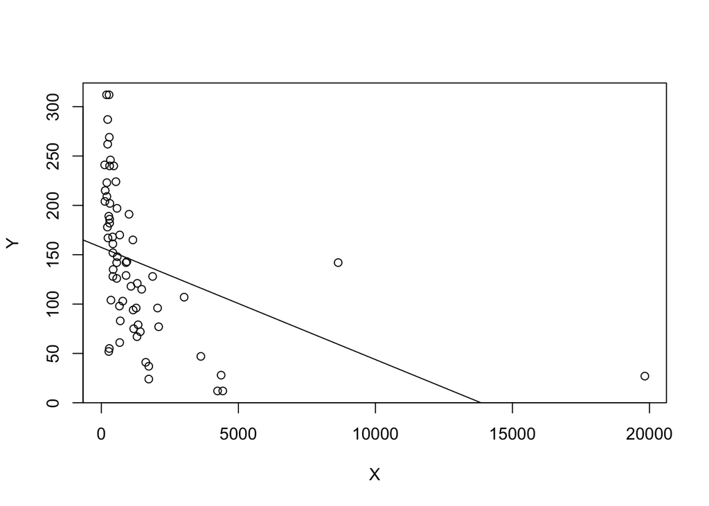

```r
plot(Y~X,data=tabla2)
# modelo1<-lm(Y~X,data=tabla2)
abline(modelo1)
```

5. Determina si el $PIB_pc$ ejerce un impacto negativo o positivo sobre la $MI$. Da una explicación de por qué era de esperarse este resultado.

El PIB parece ejercer un impacto ligeramente negativo sobre la mortalidad infantil. En general, los países con un mayor PIB per cápita suelen tener mejores infraestructuras de salud, educación y servicios sociales. Estos factores pueden contribuir a reducir la mortalidad infantil. Por ejemplo, con una mejor infraestructura de salud, los niños pueden tener acceso a vacunas y tratamientos médicos necesarios. Además, una mayor educación puede llevar a mejores prácticas de cuidado infantil y nutrición. Por lo tanto, es lógico que a medida que el PIB per cápita aumenta, la mortalidad infantil disminuya.

6. Calcula el coeficiente de determinación $R^2$

```r
summary(modelo1)
```

```
##
## Call:
## lm(formula = Y ~ X, data = tabla2)
##
## Residuals:
##      Min       1Q   Median       3Q      Max
## -113.764  -53.111   -6.685   48.064  157.758
##
## Coefficients:
##               Estimate Std. Error t value Pr(>|t|)
## (Intercept) 157.424441   9.845583  15.989  < 2e-16 ***
## X            -0.011364   0.003233  -3.516 0.000826 ***
## ---
## Signif. codes:  0 '***' 0.001 '**' 0.01 '*' 0.05 '.' 0.1 ' ' 1
##
## Residual standard error: 69.93 on 62 degrees of freedom
## Multiple R-squared:  0.1662, Adjusted R-squared:  0.1528
## F-statistic: 12.36 on 1 and 62 DF,  p-value: 0.0008262
```

```r
R2<-0.1662
R2
```

```
## [1] 0.1662
```

2. Considera ahora el alfabetismo femenino medido por la tasa de alfabetización de las mujeres (TAM). A priori, se espera que la TAM también ejerza un impacto negativo en la MI. Cuando se introducen ambas variables en el modelo, el modelo es:

$MI_i = β_1 + β_2 PIB_{pc_i} + β_3TAM_i + u_i$

Ten en cuenta que la MI es el número de muertes de niños menores de 5 años por cada 1 000 nacidos vivos, el PIBPC es el PIB per cápita en 1980 y la TAM se mide en porcentaje. La muestra se realizó en 64 países.

```r
tabla3 <- select(tabla,PIBPC,TAF,MI)
tabla3
```

```
## # A tibble: 64 × 3
##    PIBPC   TAF    MI
##    <dbl> <dbl> <dbl>
##  1  1870    37   128
##  2   130    22   204
##  3   310    16   202
##  4   570    65   197
##  5  2050    76    96
##  6   200    26   209
##  7   670    45   170
##  8   300    29   240
##  9   120    11   241
## 10   290    55    55
## # … with 54 more rows
```

1. Calcula los estimadores $\hat{\beta_1},\hat{\beta_2},\hat{\beta_3}$ para el modelo.

```r
modelo2<-lm(MI~PIBPC+TAF,data=tabla3)
summary(modelo2)$coefficients[,"Estimate"]
```

```
##   (Intercept)         PIBPC           TAF
## 263.641585620  -0.005646595  -2.231585732
```

2. Calcula el error estándar para cada estimador.

```r
summary(modelo2)$coefficients[,"Std. Error"]
```

```
## (Intercept)       PIBPC         TAF
## 11.59317932  0.00200326  0.20994721
```

3. Calcula los intervalos de confianza para los estimadores. Considera que los intervalos de confianza están dados por

$\hat{\beta_1}-t_{\alpha/2}e.e(\hat{\beta_1})\leq\beta_1\leq\hat{\beta_1}+t_{\alpha/2}e.e(\hat{\beta_1})$

$\hat{\beta_2}-t_{\alpha/2}e.e(\hat{\beta_2})\leq\beta_2\leq\hat{\beta_2}+t_{\alpha/2}e.e(\hat{\beta_2})$

$\hat{\beta_3}-t_{\alpha/2}e.e(\hat{\beta_3})\leq\beta_3\leq\hat{\beta_3}+t_{\alpha/2}e.e(\hat{\beta_3})$

donde t es la distribución t con $n − 3$ grados de libertad.

```r
confint(modelo2)
```

```
##                     2.5 %        97.5 %
## (Intercept) 240.459590828 286.823580411
## PIBPC        -0.009652361  -0.001640829
## TAF          -2.651401129  -1.811770334
```

4. Calcula el coeficiente de determinación $R^2$ y el coeficiente ajustado $R^2_{adj}$

```r
summary(modelo2)$r.squared
```

```
## [1] 0.7076655
```

```r
summary(modelo2)$adj.r.squared
```

```
## [1] 0.6980808
```

3. Para los siguientes problemas usa una significancia de α = 5%.
1. Realiza la siguiente prueba de hipótesis

$H_0 : β_2 = 0$

$H_1 : β_2\neq 0$

```r
t<-qt(1-0.05 / 2,df=64-3)
t
```

```
## [1] 1.999624
```

```r
summary(modelo2)$coefficients["PIBPC","t value"]
```

```
## [1] -2.818703
```

Tenemos evidencia suficiente para rechazar la hipótesis nula $H_0$

2. Realiza la siguiente prueba de hipótesis

$H_0 : β_3 = 0$

$H_1 : β_3\neq 0$

```r
t
```

```
## [1] 1.999624
```

```r
summary(modelo2)$coefficients["TAF","t value"]
```

```
## [1] -10.62927
```

Tenemos evidencia suficiente para rechazar la hipótesis nula $H_0$

3. Realiza la siguiente prueba de hipótesis

$H_0 : β_2 = β_3 = 0$

$H_1 : β_2\neq 0$ ó $β_3\neq0$

```r
f <- qf(1-0.05,df1=64-3,df2=3-1)
f
```

```
## [1] 19.47934
```

```r
summary(modelo2)$fstatistic[1]
```

```
##    value
## 73.83254
```

Tenemos evidencia suficiente para rechazar la hipótesis nula $H_0$ y nuestro modelo es globalmente significativo